# TS Assignment 7

Yunshuang Jiang

11/16/2020

(15 points) Question 1: Load the data and calculate the average cost of a night’s accommodation in Victoria each month (i.e. Cost variable).

```r
library(fpp)
library(tseries)
library(ggplot2)
library(forecast)
library(vars)
load("/Users/berryjiang/Downloads/motel.rda")
cost = motel[,"Takings"]*1000/motel[,"Roomnights"]
```

1. Plot the CPI and Cost time series.

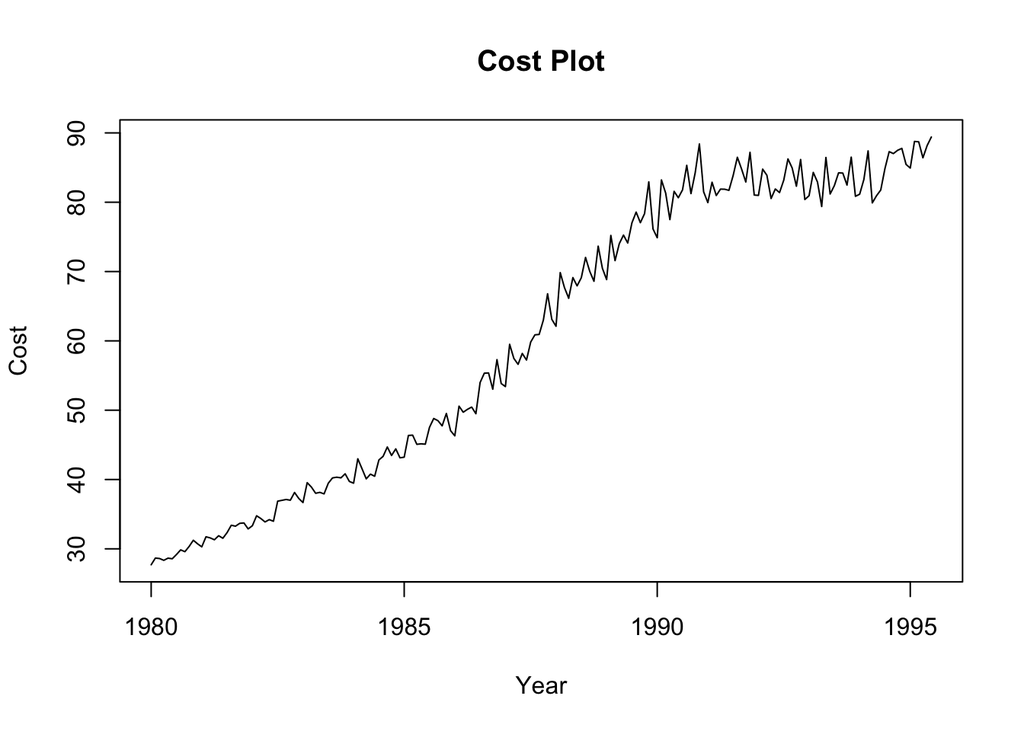

```r
plot(cost, ylab="Cost", xlab="Year", main = "Cost Plot")
```

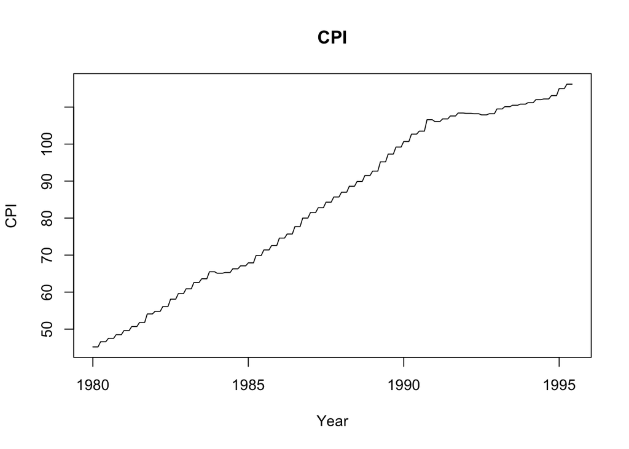

```r
plot(motel[,"CPI"], ylab="CPI", xlab="Year", main = "CPI")
```

2. Plot the Cost time series against the CPI time series and calculate the correlation between CPI and Cost.

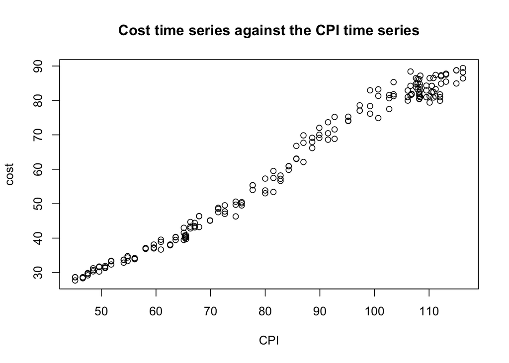

```r
plot(y=cost, x=motel[,"CPI"],ylab="cost", xlab="CPI", main = "Cost time series against the CPI time series")
```

```r
print(paste0("Correlation between CIP and Cost is: ", cor(motel[,"CPI"], cost)))
```

```
## [1] "Correlation between CIP and Cost is: 0.990718636493143"
```

Discuss your results and explain why the logarithms of both variables need to be taken before fitting any models.

Comment: The correlation between cost and CPI is too high, it is better to take log transform for both variable before fitting any models so that the variances are more stable.

3. Plot the log(CPI) and log(Cost) time series and calculate the correlation between the logarithms of both CPI and Cost.

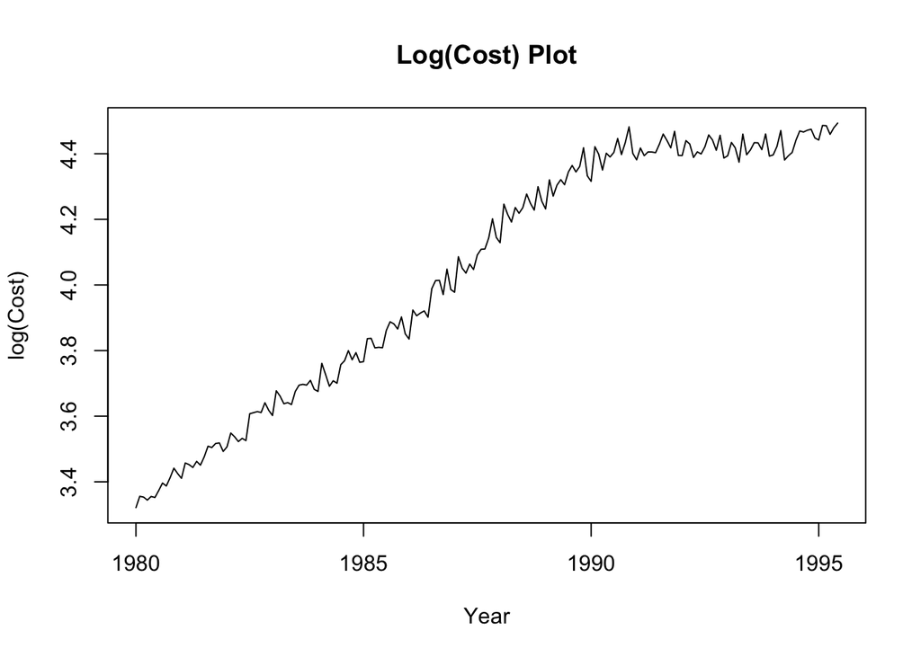

```r
logcpi = log(motel[,"CPI"])
logcost = log(cost)
plot(logcost, ylab="log(Cost)", xlab="Year", main = "Log(Cost) Plot")
```

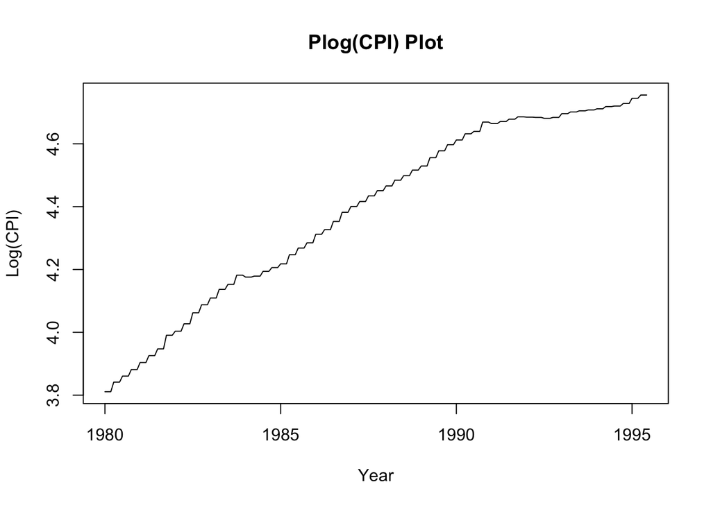

```r
plot(logcpi, ylab="Log(CPI)", xlab="Year", main = "Plog(CPI) Plot")
```

```r
print(paste0("Correlation between log(CIP) and log(Cost) is: ", cor(logcpi, logcost)))
```

```
## [1] "Correlation between log(CIP) and log(Cost) is: 0.992990203551249"
```

(15 points) Question 2: a) Use the linear model with time series components function tslm() to fit a linear model to the log(Cost) time series as a function of the log(CPI) time series (i.e., CPI ➔ Independent variable, Cost➔ Dependent variable).

```r
m1 = tslm(logcost~logcpi)
m1
```

```
##
## Call:
## tslm(formula = logcost ~ logcpi)
##
## Coefficients:
## (Intercept)       logcpi
##      -1.682        1.303
```

2. Plot log(CPI) against log(Cost) and the fitted trend.

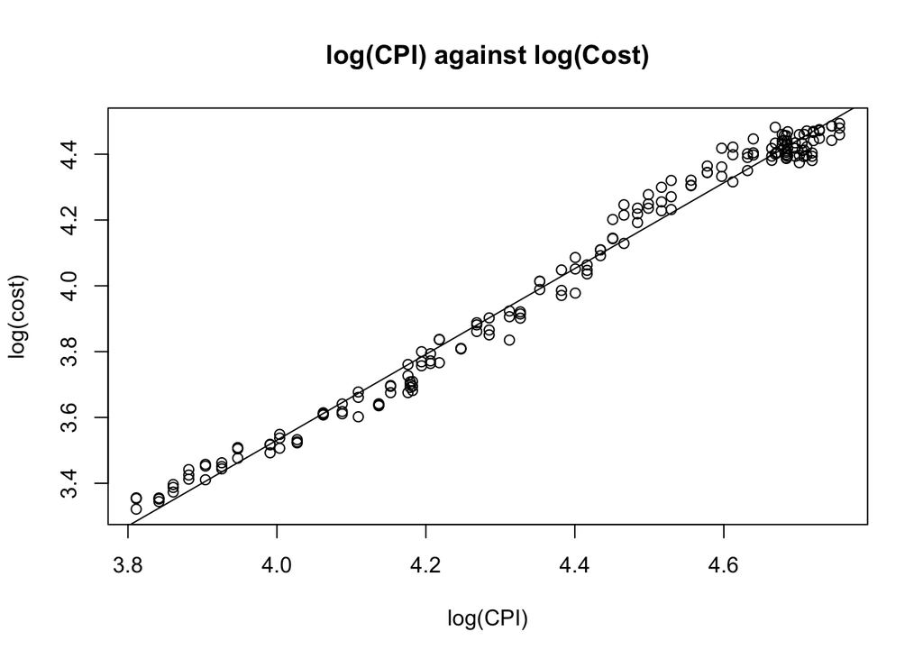

```r
plot(y=log(cost), x=logcpi,xlab="log(CPI)", ylab="log(cost)", main = "log(CPI) against log(Cost)")
abline(m1)
```

3. Use the summary() function to summarize the generated model , and the checkresiduals() function to evaluate the residuals.

```r
summary(m1)
```

```
##
## Call:
## tslm(formula = logcost ~ logcpi)
##
## Residuals:
##       Min        1Q    Median        3Q       Max
## -0.102841 -0.033939 -0.002071  0.030363  0.108670
##
## Coefficients:
##             Estimate Std. Error t value Pr(>|t|)
## (Intercept) -1.68246    0.05032  -33.44   <2e-16 ***
## logcpi       1.30339    0.01144  113.96   <2e-16 ***
## ---
## Signif. codes:  0 '***' 0.001 '**' 0.01 '*' 0.05 '.' 0.1 ' ' 1
##
## Residual standard error: 0.04487 on 184 degrees of freedom
## Multiple R-squared:  0.986,  Adjusted R-squared:  0.986
## F-statistic: 1.299e+04 on 1 and 184 DF,  p-value: < 2.2e-16
```

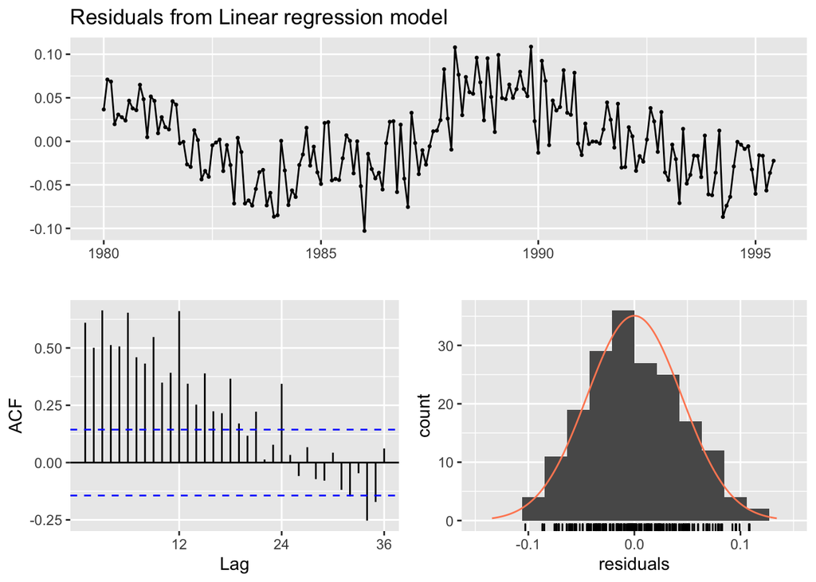

```
##
##  Breusch-Godfrey test for serial correlation of order up to 24
##
## data:  Residuals from Linear regression model
## LM test = 148.84, df = 24, p-value < 2.2e-16
```

```r
checkresiduals(m1)
```

Discuss your results.

Comment: The Breusch-Godfrey test has a p-value of smaller than 0.05, which suggestion that we can reject the null hypothesis and conclude that there is still serial correlation in the time series. The checkresiduals() graphs also suggested that there are still correlation between the residuals as the residuals graph does not look like white noise and the ACF graph has obvious multiple lags. Therefore, this model does not perform well in terms of explaining the correlation between our time series.

(10 points) Question 3: Use the auto.arima() function to fit an appropriate regression model with ARIMA errors to the Cost and CPI time series(i.e., CPI ➔ Independent variable, Cost➔ Dependent variable). Set the Order of seasonaldifferencing argument, D, to 1 and the ‘lambda’ argument to 0 to reflect a logarithmic transformation.

```r
mcpi = auto.arima(motel[,"CPI"], lambda = 0, D=1)
m2 = auto.arima(cost, xreg = mcpi$fitted, lambda = 0, D=1)
m2
```

```
## Series: cost
## Regression with ARIMA(0,1,1)(0,1,1)[12] errors
## Box Cox transformation: lambda= 0
##
## Coefficients:
##           ma1     sma1    xreg
##       -0.5411  -0.5876  0.0049
## s.e.   0.0607   0.0787  0.0025
##
## sigma^2 estimated as 0.0003935:  log likelihood=431.67
## AIC=-855.34   AICc=-855.1   BIC=-842.73
```

1. Use the summary() function to summarize the generated model.

```r
summary(m2)
```

```
## Series: cost
## Regression with ARIMA(0,1,1)(0,1,1)[12] errors
## Box Cox transformation: lambda= 0
##
## Coefficients:
##           ma1     sma1    xreg
##       -0.5411  -0.5876  0.0049
## s.e.   0.0607   0.0787  0.0025
##
## sigma^2 estimated as 0.0003935:  log likelihood=431.67
## AIC=-855.34   AICc=-855.1   BIC=-842.73
##
## Training set error measures:
##                      ME     RMSE       MAE        MPE     MAPE      MASE
## Training set -0.1195257 1.356886 0.9372912 -0.1516095 1.409933 0.2210505
##                     ACF1
## Training set -0.05458774
```

2. Use the checkresiduals() function to evaluate the residuals.

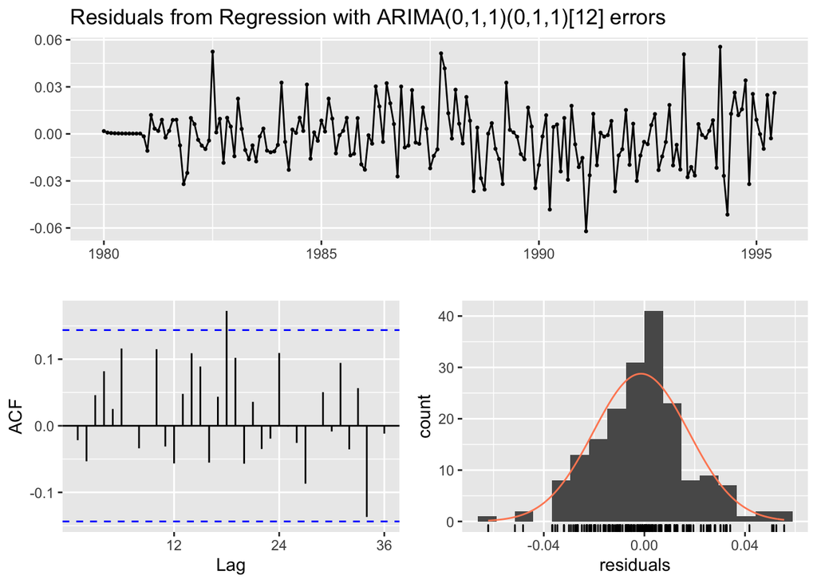

```
##
##  Ljung-Box test
##
## data:  Residuals from Regression with ARIMA(0,1,1)(0,1,1)[12] errors
## Q* = 26.518, df = 21, p-value = 0.1874
##
## Model df: 3.   Total lags used: 24
```

```r
checkresiduals(m2)
```

Discuss your results.

(10 points) Question 4: a) Calculate and plot a naïve forecast of CPI for the next 18 months.

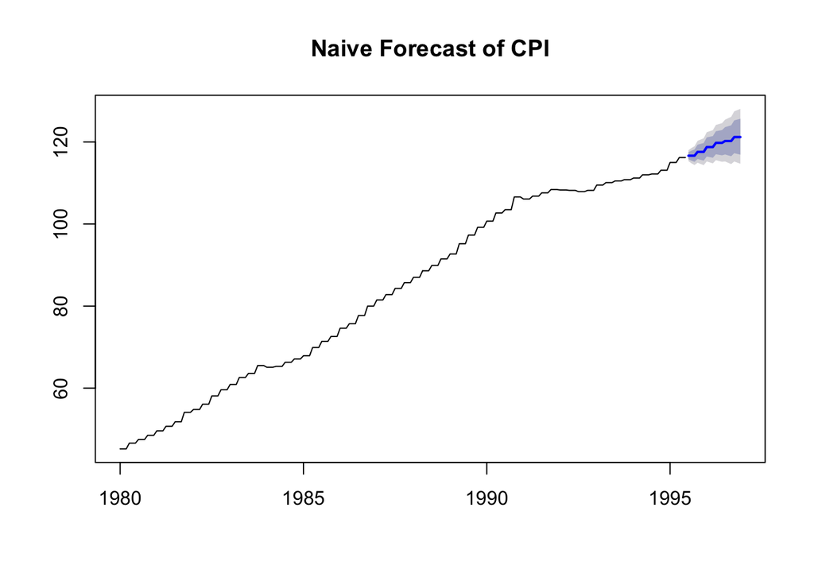

```r
fcastcpi = forecast(mcpi, h=18)
plot(fcastcpi, main = "Naive Forecast of CPI")
```

2. Forecast and plot the average price per room (i.e., Cost) for the next 18 months using the fitted model from Question 3 and the naïve forecast of CPI.

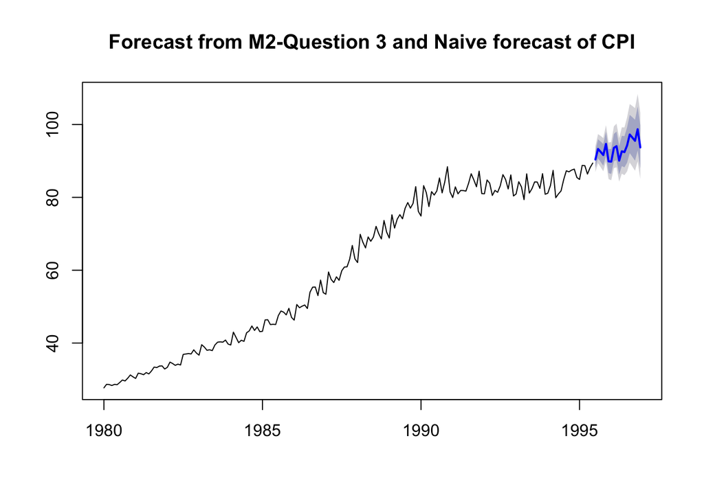

```r
fcast = forecast(m2, xreg = fcastcpi$mean,h=18)
plot(fcast, main = "Forecast from M2-Question 3 and Naive forecast of CPI")
```

Discuss your results.

(10 points) Question 5: a) Use the VAR() function to fit a VAR(10) model to the log(Cost) and log(CPI) time series. Set the ‘type’ and ‘season’ arguments to ‘both’ and 12, respectively.

```r
m3 = VAR(as.ts(data.frame(logcost = logcost, logcpi = logcpi)), p= 10, type = "both", season = 12)
summary(m3)
```

```
##
## VAR Estimation Results:
## =========================
## Endogenous variables: logcost, logcpi
## Deterministic variables: both
## Sample size: 176
## Log Likelihood: 1185.453
## Roots of the characteristic polynomial:
## 0.9752 0.9588 0.9588 0.9494 0.9494 0.8857 0.8857 0.8607 0.8607 0.858 0.858 0.7962 0.7962 0.7867 0.7765 0.7765 0.7244 0.7244 0.4201 0.4201
## Call:
## VAR(y = as.ts(data.frame(logcost = logcost, logcpi = logcpi)),
##     p = 10, type = "both", season = 12L)
##
##
## Estimation results for equation logcost:
## ========================================
## logcost = logcost.l1 + logcpi.l1 + logcost.l2 + logcpi.l2 + logcost.l3 + logcpi.l3 + logcost.l4 + logcpi.l4 + logcost.l5 + logcpi.l5 + logcost.l6 + logcpi.l6 + logcost.l7 + logcpi.l7 + logcost.l8 + logcpi.l8 + logcost.l9 + logcpi.l9 + logcost.l10 + logcpi.l10 + const + trend + sd1 + sd2 + sd3 + s…
##
##               Estimate Std. Error t value Pr(>|t|)
## logcost.l1   3.918e-01  8.566e-02   4.573 1.03e-05 ***
## logcpi.l1    3.234e-02  3.326e-01   0.097  0.92268
## logcost.l2   2.361e-01  9.172e-02   2.574  0.01107 *
## logcpi.l2    5.203e-01  4.448e-01   1.170  0.24403
## logcost.l3   2.619e-01  9.295e-02   2.818  0.00552 **
## logcpi.l3   -3.801e-01  4.452e-01  -0.854  0.39463
## logcost.l4   6.684e-02  9.548e-02   0.700  0.48503
## logcpi.l4    2.113e-01  4.446e-01   0.475  0.63539
## logcost.l5   1.064e-01  9.430e-02   1.128  0.26113
## logcpi.l5   -7.446e-01  4.443e-01  -1.676  0.09596 .
## logcost.l6   1.080e-01  9.370e-02   1.153  0.25095
## logcpi.l6    5.488e-01  4.524e-01   1.213  0.22715
## logcost.l7  -4.795e-02  9.377e-02  -0.511  0.60986
## logcpi.l7   -1.154e-02  4.533e-01  -0.025  0.97972
## logcost.l8  -1.478e-01  9.248e-02  -1.598  0.11216
## logcpi.l8   -5.395e-02  4.469e-01  -0.121  0.90407
## logcost.l9  -2.313e-02  9.246e-02  -0.250  0.80285
## logcpi.l9    2.196e-01  4.515e-01   0.486  0.62744
## logcost.l10 -5.534e-03  8.677e-02  -0.064  0.94924
## logcpi.l10  -2.696e-01  3.302e-01  -0.817  0.41554
## const       -9.512e-02  1.711e-01  -0.556  0.57905
```

[output cut: 63 more lines]

```
## Residual standard error: 0.004535 on 143 degrees of freedom
## Multiple R-Squared: 0.9998,  Adjusted R-squared: 0.9997
## F-statistic: 1.855e+04 on 32 and 143 DF,  p-value: < 2.2e-16
##
##
##
## Covariance matrix of residuals:
##           logcost    logcpi
## logcost 3.704e-04 1.699e-05
## logcpi  1.699e-05 2.057e-05
##
## Correlation matrix of residuals:
##         logcost logcpi
## logcost  1.0000 0.1947
## logcpi   0.1947 1.0000
```

```r
serial.test(m3)
```

```
##
##  Portmanteau Test (asymptotic)
##
## data:  Residuals of VAR object m3
## Chi-squared = 20.5, df = 24, p-value = 0.668
```

2. Forecast and plot the average price per room (i.e., Cost) and CPI for the next 18 months using your fitted model.

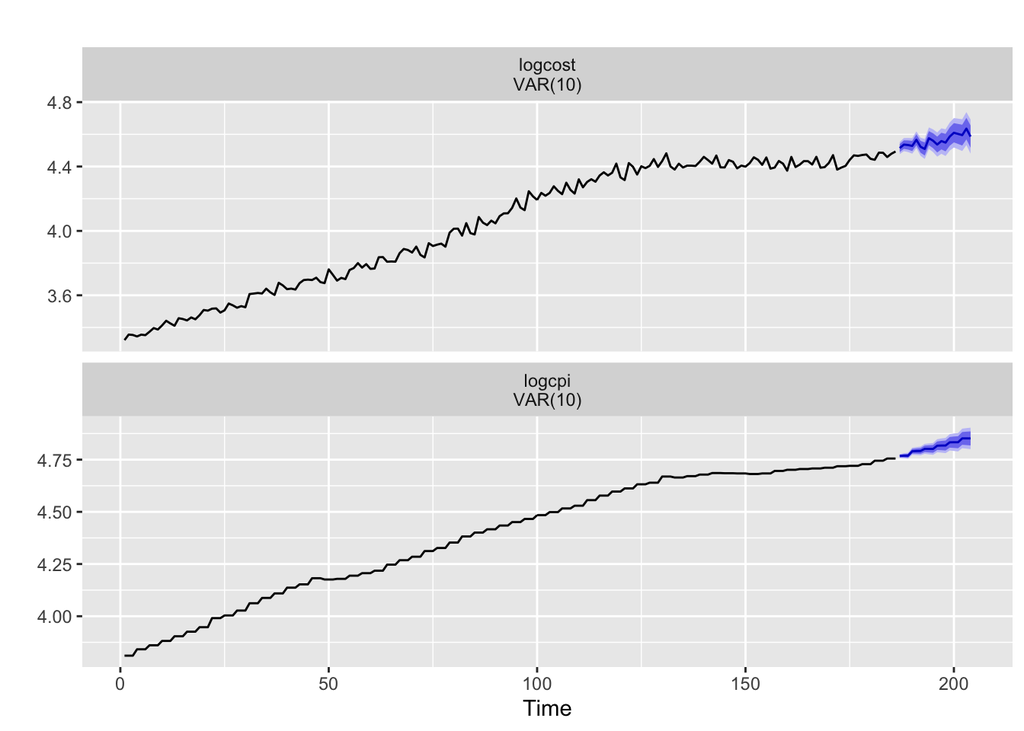

```r
autoplot(forecast(m3, h=18))
```

3. Plot the acf of residuals.

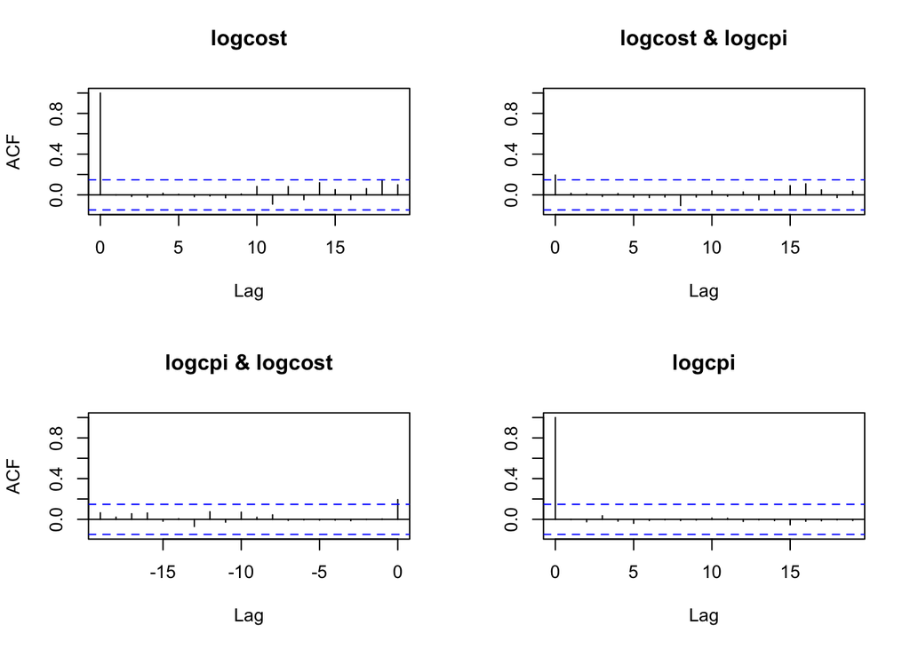

```r
acf(residuals(m3))
```

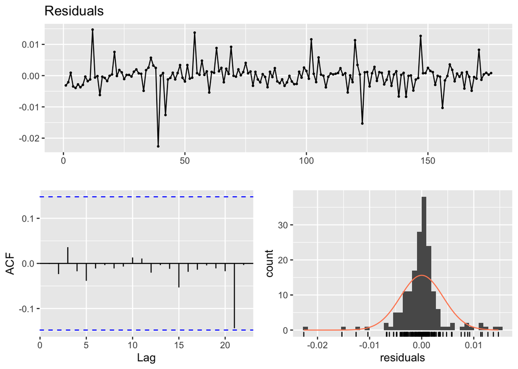

```
##
##  Breusch-Godfrey test for serial correlation of order up to 36
##
## data:  Residuals
## LM test = 32.303, df = 36, p-value = 0.6452
```

```r
checkresiduals(m3$varresult$logcpi)
```

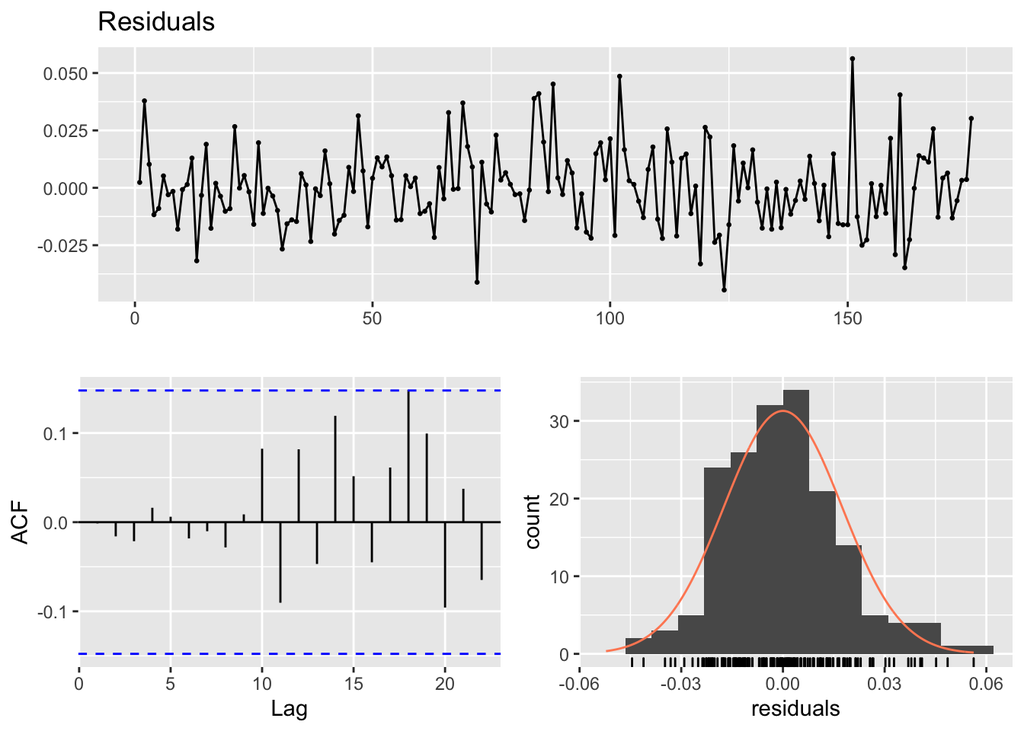

```
##
##  Breusch-Godfrey test for serial correlation of order up to 36
##
## data:  Residuals
## LM test = 54.74, df = 36, p-value = 0.02346
```

```r
checkresiduals(m3$varresult$logcost)
```

Discuss your results.